# A Pan-Cancer Analysis of Gene Expression Data Across 32 Tissues

## Motive

### Why this topic?

- Cancer is a leading cause of death worldwide
- 1,000,000 new diagnosed
- Over 600,000 deaths
- Data is convenient to obtain and analyze

## Background

### What is cancer?

#### **Cancer** is a group of diseases characterized with abnormal growth of cells

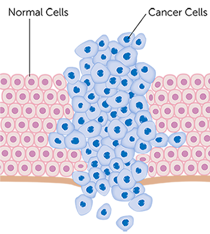

https://mary-crowley-web.s3.amazonaws.com/media/filer_public/00/fe/00fe9aa2-018f-42d1-80ae-6b6ea8ec35ae/cancer-cells.png

## Background Cont.

### How to study cancer?

- Measure gene expression
- A **gene** is a fragment of DNA that expresses a cellular function

[figure not shown]

https://ghr.nlm.nih.gov/primer/illustrations/geneinchromosome.jpg

## Background Cont.

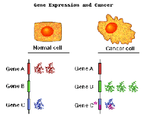

https://www.ncbi.nlm.nih.gov/Class/MLACourse/Original8Hour/Genetics/gene_expression.html

## Data

### The Cancer Genome Atlas (TCGA)

- Collaborative source for cancer data

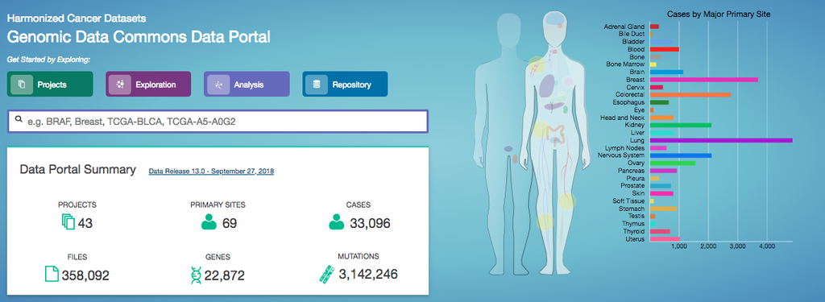

## Data Cont.

We downloaded gene expression of 32 human tissues from TCGA

- TCGAbiolinks

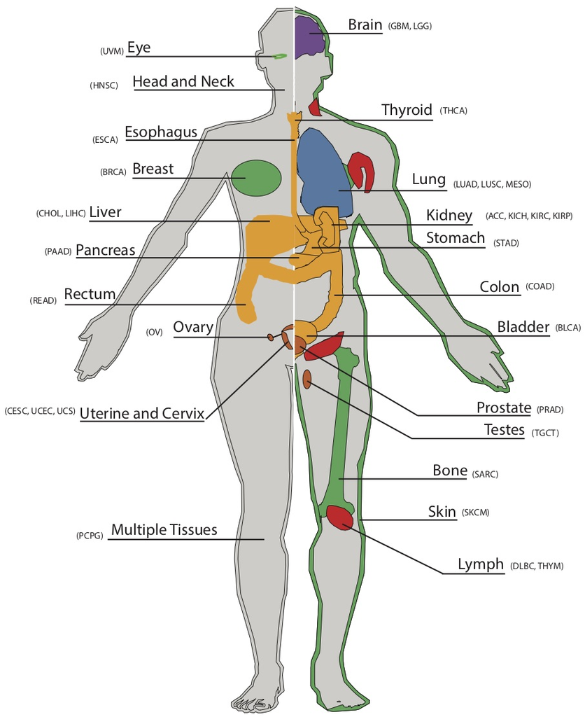

## Data Cont.

### The Cancer Genome Atlas (TCGA)

We downloaded gene expression of 32 human tissues  
Samples

- Tumor and "normal" tissues

[figure not shown]

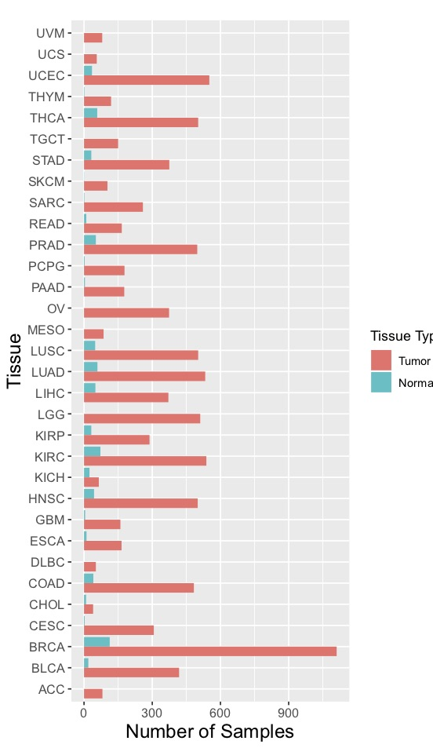

## Data Cont.

### The Cancer Genome Atlas (TCGA)

We downloaded gene expression of 32 human tissues  
Samples

- Tumor and "normal" tissues
- Number of samples vary
- Not all tissues have normal samples

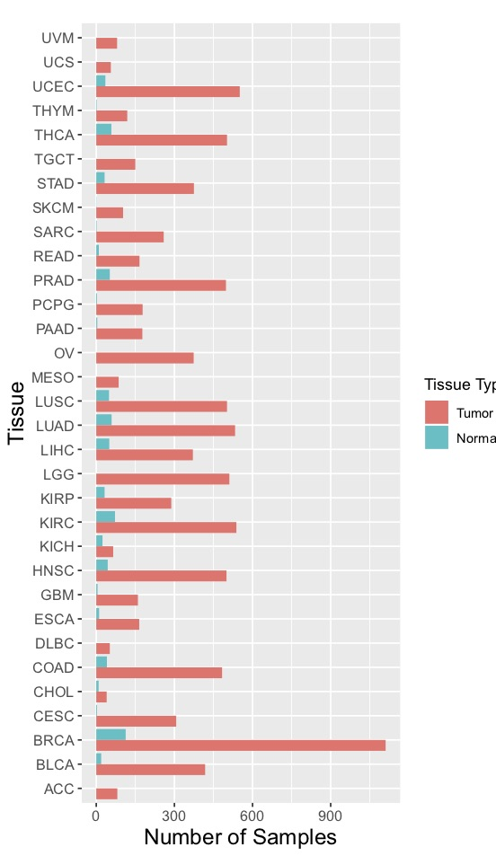

## Objective

1. Identify difference of expression in selected genes between normal and tumor tissues using visualizations
2. Identify difference of expression in all genes between normal and tumor tissues using paired t-test

## Literature Review

Two of the main type of genes that play a role in cancer

- **Tumor suppressors:** Normal genes that slow down cell division, repair DNA mistakes, or tell cells when to die
- BRCA1
- BRCA2
- TP53
- **Oncogenes:** If a gene that is responsible for cell to grow become permanently activated when it is not supposed to be.
- KRAS
- MYC
- ABL1

[figure not shown]

## Gene Location on Chromosomes

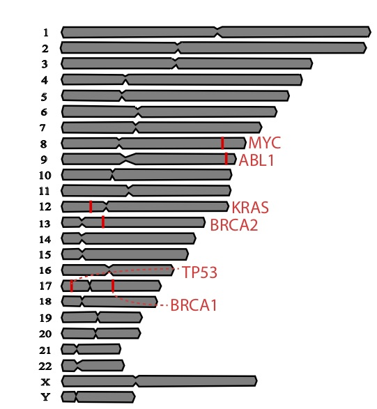

## Results

### Heat Maps

- Most Common way to visualize Gene Expression Data
- Shiny App: https://ajvanderwal.shinyapps.io/ShinyApp/
- Each column represents a Gene (BRCA1, BRCA2, TP53, KRAS, MYC, and ABL1)
- Each row represents a sample
- Red indicates high gene expression, green indicates low gene expression
- High Gene Expression does not indicate tumor

[interactive chart not shown]

## Results Cont.

### Heat Maps

- Overexpression of the MYC gene in most of the tissues analyzed
- CESC, KICH, TGCT are the tissues with an exception and have low expression
- No expression in normal nor tumor across all tissues for BRCA1 & BRCA2
- Slight Expression of BRCA1 in TGCT
- 40% of the tissues show a high expression of TP53
- Similarly, 43% of the tissues have a high expression of ABL1
- ABL1 and KRAS are more expressed in tumor tissues

## Results Cont.

### Boxplots

- Allows viewer to visualize the distribution of each gene's expressiveness
- Tumor samples have higher expression and more spread

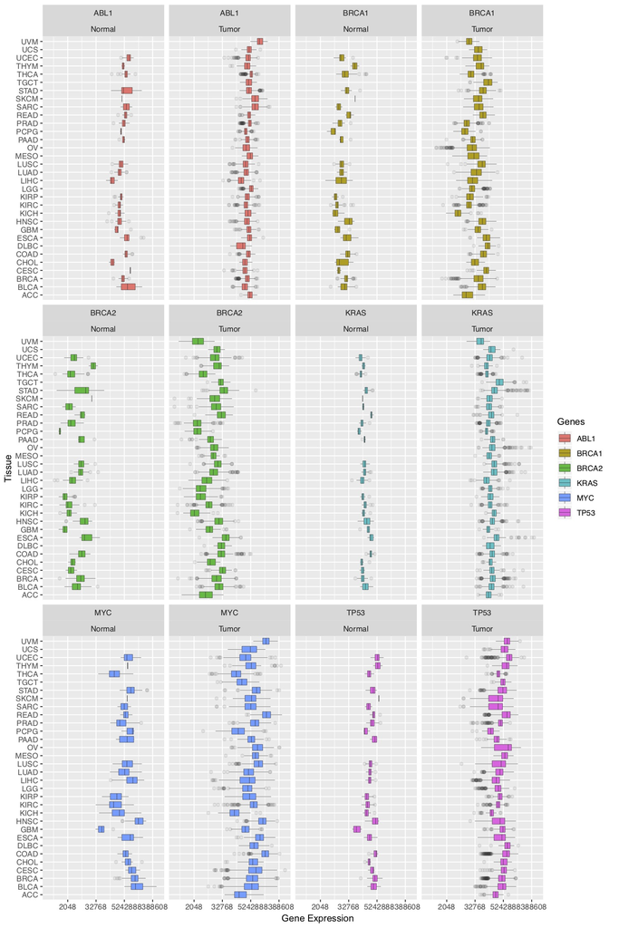

## Results Cont.

### Paired t-Test

- Goal is to see which tissues have a statistically significant difference between tumor and normal gene expression
- Averaged all samples' expression for all 60,483 genes
- Conducted t-test using all 60,483 genes of a tissue
- Difference between tumor gene expression average and normal gene expression average

## Results Cont.

### Paired t-Test

- Goal is to see which tissues have a statistically significant difference between tumor and normal gene expression
- Averaged all samples' expression for all 60,483 genes
- Conducted t-test using all 60,483 genes of a tissue
- Difference between tumor gene expression average and normal gene expression average

## Tumor Tissue

Real data had 60,483 genes  
Number of tumor samples is N (varied for each tissue)

| Gene | Sample 1 | Sample 2 | … | Sample N |
| --- | --- | --- | --- | --- |
| ENSG00000242268 | 232.9 | 96.3 | … | 530.7 |
| ENSG00000244268 | 0 | 10.4 | … | 0 |
| ENSG00000457068 | 7998.2 | 4830.9 | … | 103372.4 |
|  | … | … | … | … |
| ENSG00000952268 | 9384064.3 | 4920507.3 | … | 18203953.2 |

## Normal Tissue

Real data had 60,483 genes  
Number of normal samples is S (varied for each tissue)  
N and S does not need to be the same

| Gene | Sample 1 | Sample 2 | … | Sample S |
| --- | --- | --- | --- | --- |
| ENSG00000242268 | 23.1 | 148.3 | … | 98.3 |
| ENSG00000244268 | 56.9 | 278.7 | … | 342 |
| ENSG00000457068 | 0 | 0 | … | 0 |
|  | … | … | … | … |
| ENSG00000952268 | 2351.3 | 3213.9 | … | 2332.2 |

## Paired t-Test

t-Test is uses each gene (60,483) as the samples and uses the tumor average and normal average as the values  
This is done throughout cancer research

| Gene | Tumor Average | Normal Average |
| --- | --- | --- |
| ENSG00000242268 | 983.6 | 101.8 |
| ENSG00000244268 | 70.1 | 643.2 |
| ENSG00000457068 | 8749.5 | 983.2 |
|  | … | … |
| ENSG00000952268 | 102934.3 | 2022.3 |

## Paired t-Test Results

| Tissue | n | t Statistic | p Value | Mean of Difference | 95% Confidence Interval |
| --- | --- | --- | --- | --- | --- |
| HNSC | 60,483 | -5.0159 | 0.0000 | -51655.27 | (-71839.91, -31470.62) |
| KIRP | 60,483 | 4.3660 | 0.0000 | 21988.02 | (12117.12, 31858.93) |
| LIHC | 60,483 | -4.6364 | 0.0000 | -138267.41 | (-196718.89, -79815.93) |
| STAD | 60,483 | -7.4616 | 0.0000 | -79646.53 | (-100567.87, -58725.19) |
| UCEC | 60,483 | 6.4985 | 0.0000 | 27033.27 | (18879.79, 35186.75) |
| KICH | 60,483 | 3.8394 | 0.0001 | 109173.65 | (53440.82, 164906.48) |
| THCA | 60,483 | 4.0427 | 0.0001 | 16474.15 | (8487.09, 24461.21) |
| COAD | 60,483 | -2.9470 | 0.0032 | -14363.75 | (-23916.84, -4810.65) |
| LUSC | 60,483 | -0.8799 | 0.3789 | -4962.00 | (-16015.15, 6091.15) |
| BRCA | 60,483 | -0.5383 | 0.5903 | -1663.95 | (-7722.14, 4394.24) |

## Summary

- Downloaded and analyzed samples from TCGA (32 tissues)
- Visualized gene expression of 6 genes related to cancer (heat maps and boxplots)
- Performed paired t-test to find significant difference between normal and tumor tissue samples

## Future Directions

- Obtain more normal tissue samples
- Visualized gene expression of 6 genes related to cancer (heat maps and boxplots)
- Analyze more data by capturing other features (mutation rate, copy number, fusion, etc.)
- Statistically analyze individual genes
- Use other techniques to analyze genes (non-parametric statistics, ML clustering algorithms, etc.)